# National Parks Visitation

Charles Coonce

2023-11-13

# Executive Summary

This project explores over a century of US National Park visitation data (1904–2016) to answer key questions about park popularity, regional trends, and route optimization. The study: - Explores visitation trends over time. - Analyzes patterns by region and state. - Maps park locations and visualizes visitation intensity. - Performs distance analyses to consider travel logistics. - Clusters parks and uses the Traveling Salesman Problem (TSP) framework to suggest efficient multi-park itineraries.

The findings can help guide travel planning decisions, whether for a single park visit or a multi-park road trip.

## Introduction

Understanding patterns in national park visitation can provide insights into tourism trends, inform infrastructure planning, and help individuals optimize travel plans. In this project, I combine traditional data exploration with spatial analytics and route optimization to provide actionable insights for park visitors.

Data Preparation and Setup

Below we load the necessary libraries, import the dataset, and perform initial cleaning.

# Load and Clean Data

We start by importing the [visitation dataset](https://data.world/inform8n/us-national-parks-visitation-1904-2016-with-boundaries/workspace/file?filename=All+National+Parks+Visitation+1904-2016.csv) and removing problematic observations. In particular, we convert the YearRaw field to numeric (removing the “Total” rows) and omit rows with missing values.

```r
  ## Getting my Data Set
data <- read.csv("assets/Data Sources/US_NPS_Visitation/original/All National Parks Visitation 1904-2016.csv")

  ## Select key columns and remove missing values
data_clean <- select(data, Region:YearRaw) %>%
  na.omit()

  ## Remove the "Total" rows and convert YearRaw to numeric
data_totals <- subset(data_clean, YearRaw == "Total")
data_clean <- subset(data_clean, YearRaw != "Total")
data_clean$YearRaw <- as.numeric(data_clean$YearRaw)
```

# Exploratory Analysis

National Park Visitation Trends

We aggregate the visitor counts by year and create a line plot to visualize the overall upward trend in national park visitation over time.

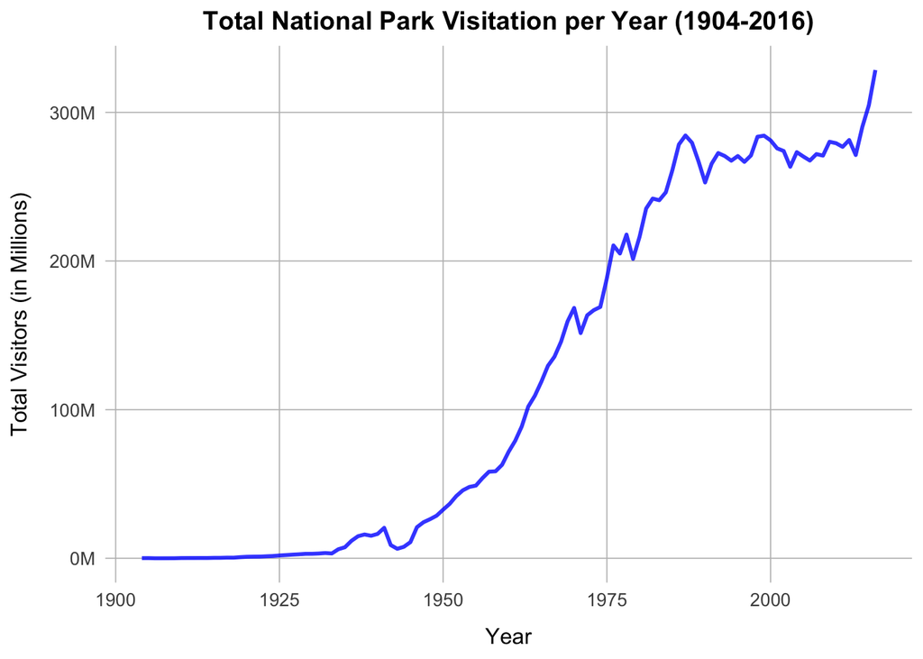

[figure not shown]

National Parks Service Regions - This poster explains the region categories used in this data set.

# Regional Analysis

The data set is subdivided into regions as shown in the info graphic above.

Next, we explore visitation by region. We filter for the regions of interest (Pacific West “PW”, Intermountain “IM”, and Midwest “MW”) and then visualize these trends in separate panels.

```r
# Group by Year and Region for selected regions
region_total <- data_clean %>%
  filter(Region %in% c("PW", "IM", "MW")) %>%
  group_by(YearRaw, Region) %>%
  summarise(Total = sum(Visitors), .groups = "drop") %>%
  na.omit()
```

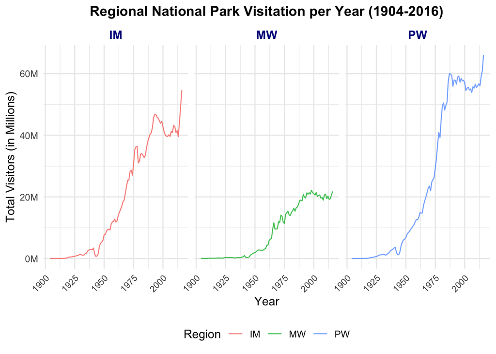

# State-Level Analysis and Mapping

We further examine visitation totals by state. We then merge state-level visitor data with geographic data to create a heatmap of visitation across selected western US states.

## Prepare State Data and Map

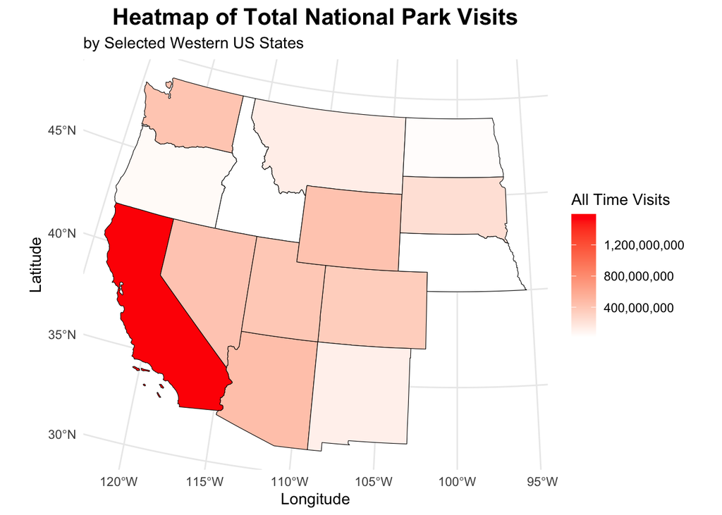

```r
# Aggregate visitation by state for selected states
state_data <- data_clean %>%
  group_by(State) %>%
  summarise(Total = sum(Visitors)) %>%
  filter(State %in% c("WA", "OR", "CA", "MT", "WY",
                      "CO", "UT", "NV", "ND", "SD",
                      "NE", "ID", "AZ", "NM"))

# Get map data for the states
states_map <- usmap::us_map(regions = "states") %>%
  filter(abbr %in% unique(state_data$State))

# Merge visitor data with map data
merged_data <- merge(states_map, state_data, by.x = "abbr", by.y = "State", all.x = TRUE)
```

# Bubble Plot for Top Parks

Based on visitation totals, we extract the top parks and merge with pre-collected geographic coordinates. This enables us to produce a bubble plot overlaid on a US map.

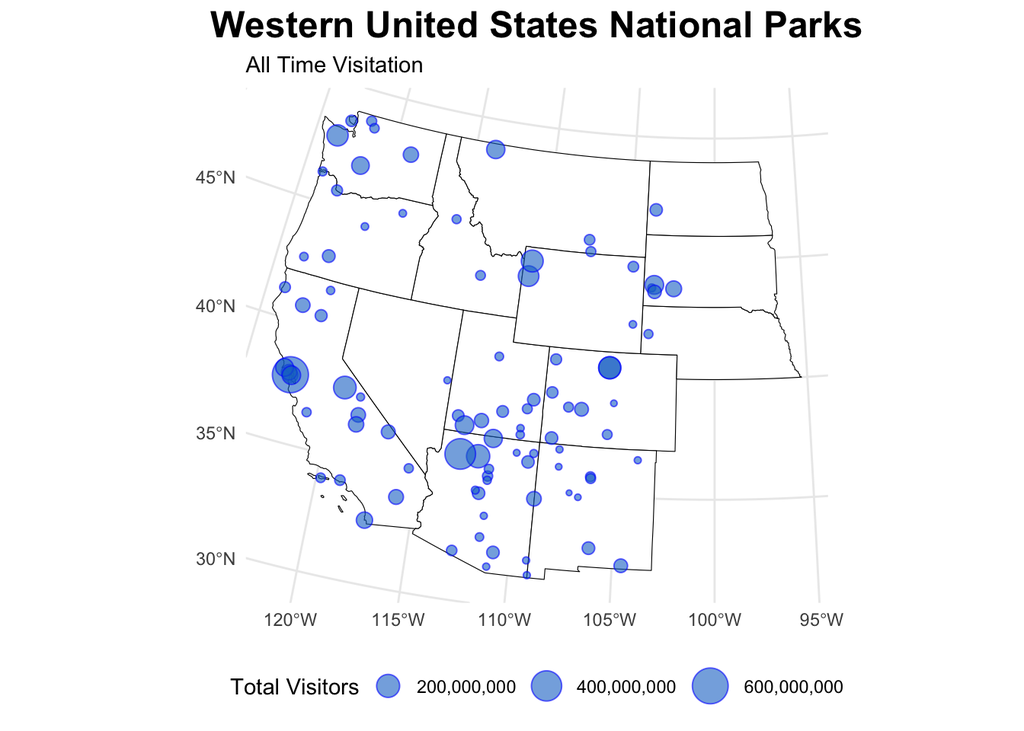

```r
# Aggregate visitation by park for selected states
top_parks <- data_clean %>%
  group_by(Unit.Name, State) %>%
  summarise(Total = sum(Visitors), .groups = "drop") %>%
  arrange(desc(Total)) %>%
  filter(State %in% c("WA", "OR", "CA", "MT", "WY",
                      "CO", "UT", "NV", "ND", "SD",
                      "NE", "ID", "AZ", "NM"))

# Load external geographic coordinates
geo_data <- read_csv("~/Documents/GitHub/National_Parks_Project/assets/Data Sources/geo_data_processed.txt",
                     col_types = cols(Lat = col_number(), Long = col_number()))

# Merge coordinate data with top parks
top_parks_merged <- merge(top_parks, geo_data,
                          by.x = "Unit.Name", by.y = "Park Name")
top_parks_rearranged <- select(top_parks_merged, Unit.Name, State.x, Total, Longitude, Latitude)
```

# Distance Analysis

To plan efficient travel routes, it is important to consider distances.

Here we: 1. Define a home location (Helena, MT). 2. Use the OSRM API to obtain route geometries from home to each top park. 3. Calculate route distances.

## Obtain and Calculate Routes

```r
# Define home coordinates for Helena, MT
helena_coords <- data.frame(Latitude = 46.5891, Longitude = -112.0372)
helena_sf <- st_as_sf(helena_coords, coords = c("Longitude", "Latitude"), crs = 4326)

# Prepare the top parks data for routing
top_parks_merged_sf <- st_as_sf(top_parks_merged,
                                coords = c("Longitude", "Latitude"),
                                crs = 4326)

# Define a function to get route coordinates from OSRM
get_route <- function(start, end) {
  url <- paste0(
    "http://router.project-osrm.org/route/v1/driving/",
    start["lon"], ",", start["lat"], ";",
    end["Longitude"], ",", end["Latitude"],
    "?overview=full&geometries=geojson"
  )

  response <- httr::GET(url)
  route <- jsonlite::fromJSON(content(response, "text", encoding = "UTF-8"))
  route_coords <- route$routes$geometry$coordinates[[1]]
  route_coords_df <- data.frame(
    lon = route_coords[, 1],
    lat = route_coords[, 2]
  )
  return(route_coords_df)
}

# Set starting point (Helena, MT)
start <- c(lat = 46.5891, lon = -112.0372)

# Get routes from Helena to each park
routes_list <- lapply(1:nrow(top_parks_merged), function(i) {
  end <- top_parks_merged[i, ]
  route_df <- get_route(start, end)
  route_df$park <- top_parks_merged$Unit.Name[i]
  return(route_df)
})

all_routes <- do.call(rbind, routes_list)

# Calculate total distance (in miles) for each route using the Vincenty formula
meters_to_miles <- 1609.34
calculate_total_distance_miles <- function(df) {
  df$lon <- as.numeric(df$lon)
  df$lat <- as.numeric(df$lat)
  coords <- as.matrix(df[, c("lon", "lat")])
  distances <- distVincentySphere(coords[1:(nrow(coords) - 1), ], coords[2:nrow(coords), ])
  total_distance_meters <- sum(distances)
  total_distance_miles <- total_distance_meters / meters_to_miles
  return(total_distance_miles)
}

total_distances_miles <- sapply(routes_list, calculate_total_distance_miles)

# Attach distance information to each route
routes_list <- Map(function(df, dist) {
  df$total_distance_miles <- dist
  return(df)
}, routes_list, total_distances_miles)

all_routes <- bind_rows(routes_list)
```

# Visualize Routes

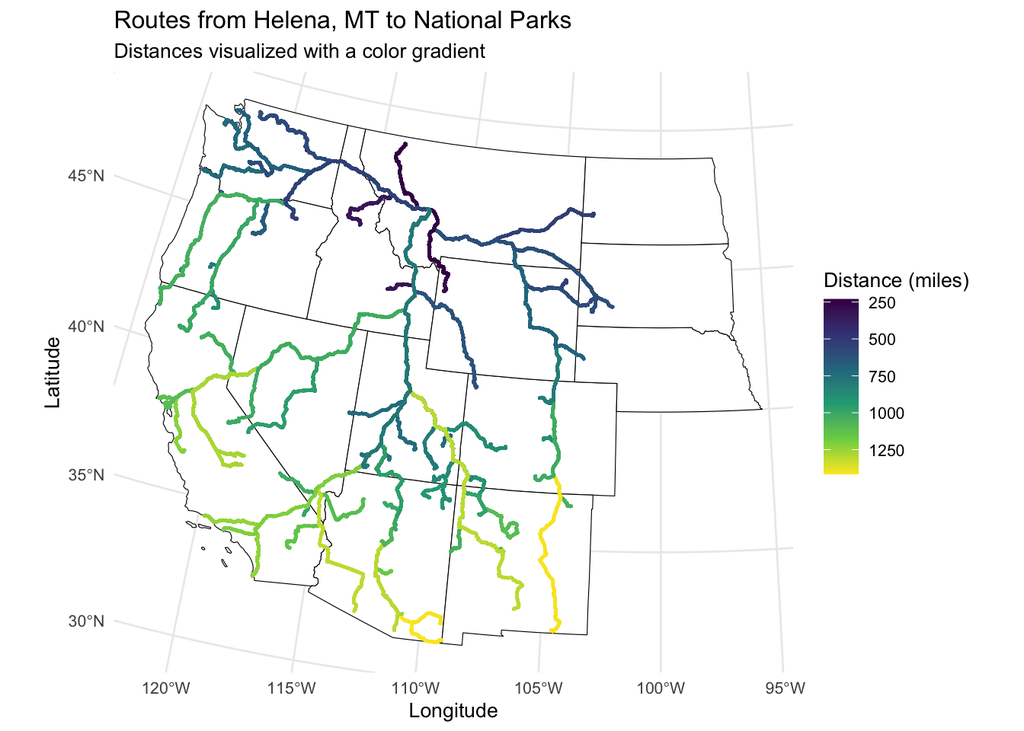

# Clustering and Route Optimization

With many nearby parks, it may be more efficient to plan a multi-park trip. We use hierarchical clustering to group parks by geographic proximity, then apply the Traveling Salesman Problem (TSP) algorithm to suggest the optimal visiting order within each cluster.

## Cluster Parks

```r
# For clustering, we work with the top parks data with coordinates
top_parks_cluster <- top_parks_merged

# Define a helper function to compute pairwise distances (in kilometers)
calculate_distance <- function(lat1, lon1, lat2, lon2) {
  distVincentySphere(c(lon1, lat1), c(lon2, lat2)) / 1000
}

# Create a distance matrix between parks
num_parks <- nrow(top_parks_cluster)
distance_matrix <- matrix(0, nrow = num_parks, ncol = num_parks)
rownames(distance_matrix) <- top_parks_cluster$Unit.Name
colnames(distance_matrix) <- top_parks_cluster$Unit.Name

for (i in 1:num_parks) {
  for (j in 1:num_parks) {
    if (i != j) {
      distance_matrix[i, j] <- calculate_distance(
        top_parks_cluster$Latitude[i],
        top_parks_cluster$Longitude[i],
        top_parks_cluster$Latitude[j],
        top_parks_cluster$Longitude[j]
      )
    }
  }
}

# Perform hierarchical clustering
dist_matrix <- dist(top_parks_cluster[, c('Longitude', 'Latitude')])
clusters <- hclust(dist_matrix)
park_clusters <- cutree(clusters, k = 5)
top_parks_cluster$cluster <- park_clusters
```

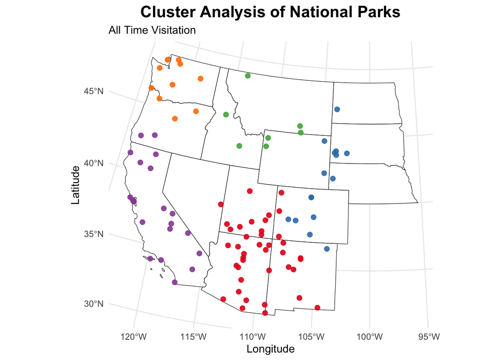

Now we want to know what the most efficient way to drive from park to park is so we will use the Traveling Salesman Problem (TSP). The TSP finds shortest possible route that visits each city exactly once and returns to the original city.

```r
  ## Initialize an empty list to store results
tsp_results <- list()

  ## Loop through each cluster
for (i in 1:max(top_parks_cluster$cluster)) {
    ## Subset parks for the current cluster
  cluster_parks <- top_parks_cluster[top_parks_cluster$cluster == i, ]

    ## Calculate the distance matrix for the current cluster
  dist_matrix <- as.dist(distm(cluster_parks[, c("Longitude", "Latitude")],
                               cluster_parks[, c("Longitude", "Latitude")],
                               fun = distHaversine))

    ## Solve the TSP problem using the nearest neighbor heuristic
  tsp_solution <- solve_TSP(TSP(dist_matrix), method = "nearest_insertion")

    ## Solution List
  tsp_results[[paste("Cluster", i)]] <- tsp_solution
}
```

```
## object of class 'TOUR'
## result of method 'nearest_insertion' for 40 cities
## tour length: 5647527
## object of class 'TOUR'
## result of method 'nearest_insertion' for 15 cities
## tour length: 2831039
## object of class 'TOUR'
## result of method 'nearest_insertion' for 7 cities
## tour length: 1870478
## object of class 'TOUR'
## result of method 'nearest_insertion' for 22 cities
## tour length: 3442258
## object of class 'TOUR'
## result of method 'nearest_insertion' for 10 cities
## tour length: 1645687
```

Next, we use the OSRM API to get detailed route geometries for each segment and then visualize them on our base map.

```r
# Function to get route coordinates from OSRM
get_route_osrm <- function(start_lon, start_lat, end_lon, end_lat) {
  url <- paste0(
    "http://router.project-osrm.org/route/v1/driving/",
    start_lon, ",", start_lat, ";",
    end_lon, ",", end_lat,
    "?overview=full&geometries=geojson"
  )

  response <- GET(url)
  route <- fromJSON(content(response, "text", encoding = "UTF-8"))

  route_coords <- route$routes$geometry$coordinates[[1]]
  route_coords_df <- data.frame(
    lon = route_coords[, 1],
    lat = route_coords[, 2]
  )
  return(route_coords_df)
}

# Apply the function to each row in the data frame
routes_list_cluster <- lapply(1:nrow(all_segments_df), function(i) {
  start_lon <- all_segments_df$x[i]
  start_lat <- all_segments_df$y[i]
  end_lon <- all_segments_df$xend[i]
  end_lat <- all_segments_df$yend[i]

  route <- get_route_osrm(start_lon, start_lat, end_lon, end_lat)

  route_df <- data.frame(id = i, cluster =all_segments_df$cluster[i], route)

  return(route_df)
})

# Combine all route data frames into one
all_cluster_routes_df <- do.call(rbind, routes_list_cluster)

# Create an sf object from the combined data frame
routes_sf <- st_as_sf(all_cluster_routes_df, coords = c("lon", "lat"), crs = 4326, agr = "constant")

routes_sf_lines <- routes_sf %>%
  group_by(id, cluster) %>%
  summarize(geometry = st_combine(geometry)) %>%
  st_cast("LINESTRING")
```

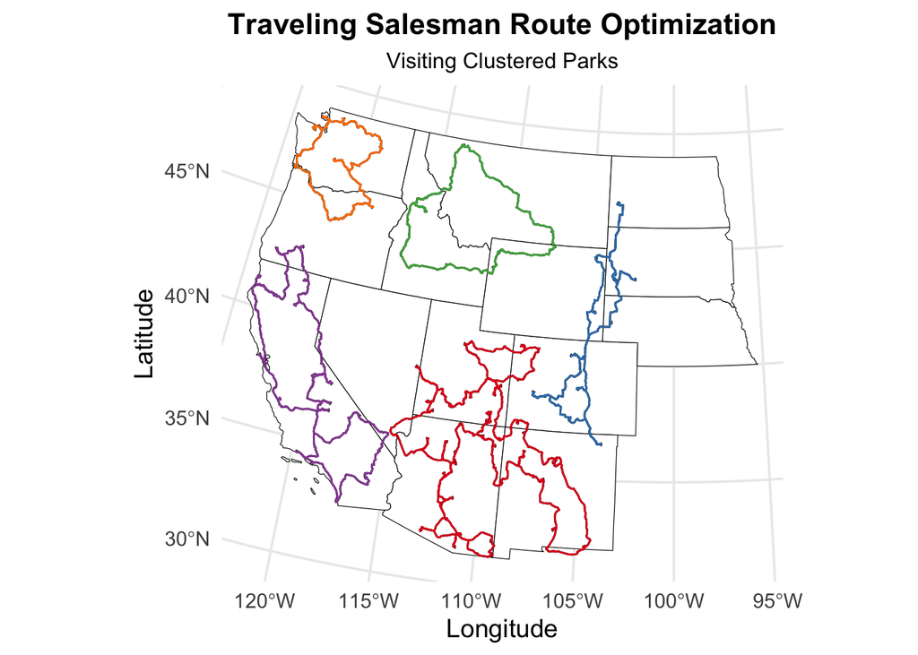

# Conclusion

This portfolio project demonstrates a full workflow for transforming raw visitation data into actionable insights:

```
-   Temporal and regional analyses reveal long-term trends and popular areas.
-   Spatial visualizations help pinpoint high-traffic parks.
-   Route optimization via clustering and TSP supports efficient multi-park trip planning.
```

These methods can be further extended or tailored for specific travel planning applications or more granular analyses of park visitor data.

## Future work might include:

```
- Re-clustering for smaller number of parks per loop.
- Refining clustering parameters and TSP heuristics.
-   Incorporating real-time traffic data into route optimization.
-   Developing an interactive dashboard for dynamic travel planning.
```